# Regression Tree & Classification Tree

YUANXU

10/23/2020

```r
library(ISLR)
library(tree)
```

## Using OJ(orange juice data),split the data into training set and test set, this time we use real numbers not percentage

```r
attach(OJ)
dim(OJ)
```

```
## [1] 1070   18
```

```r
set.seed(1)
subset = sample(1:nrow(OJ),800)
OJ.train = OJ[subset,]
OJ.test = OJ[-subset,]
dim(OJ.train)
```

```
## [1] 800  18
```

## Build a tree model based on the training set the tree package will automatically pick the impoartant indicators

```r
tree.OJ = tree(Purchase~.,data = OJ.train)
summary(tree.OJ)
```

```
##
## Classification tree:
## tree(formula = Purchase ~ ., data = OJ.train)
## Variables actually used in tree construction:
## [1] "LoyalCH"       "PriceDiff"     "SpecialCH"     "ListPriceDiff"
## [5] "PctDiscMM"
## Number of terminal nodes:  9
## Residual mean deviance:  0.7432 = 587.8 / 791
## Misclassification error rate: 0.1588 = 127 / 800
```

##List the details of the tree and plot the tree

```r
tree.OJ
```

```
## node), split, n, deviance, yval, (yprob)
##       * denotes terminal node
##
##  1) root 800 1073.00 CH ( 0.60625 0.39375 )
##    2) LoyalCH < 0.5036 365  441.60 MM ( 0.29315 0.70685 )
##      4) LoyalCH < 0.280875 177  140.50 MM ( 0.13559 0.86441 )
##        8) LoyalCH < 0.0356415 59   10.14 MM ( 0.01695 0.98305 ) *
##        9) LoyalCH > 0.0356415 118  116.40 MM ( 0.19492 0.80508 ) *
##      5) LoyalCH > 0.280875 188  258.00 MM ( 0.44149 0.55851 )
##       10) PriceDiff < 0.05 79   84.79 MM ( 0.22785 0.77215 )
##         20) SpecialCH < 0.5 64   51.98 MM ( 0.14062 0.85938 ) *
##         21) SpecialCH > 0.5 15   20.19 CH ( 0.60000 0.40000 ) *
##       11) PriceDiff > 0.05 109  147.00 CH ( 0.59633 0.40367 ) *
##    3) LoyalCH > 0.5036 435  337.90 CH ( 0.86897 0.13103 )
##      6) LoyalCH < 0.764572 174  201.00 CH ( 0.73563 0.26437 )
##       12) ListPriceDiff < 0.235 72   99.81 MM ( 0.50000 0.50000 )
##         24) PctDiscMM < 0.196197 55   73.14 CH ( 0.61818 0.38182 ) *
##         25) PctDiscMM > 0.196197 17   12.32 MM ( 0.11765 0.88235 ) *
##       13) ListPriceDiff > 0.235 102   65.43 CH ( 0.90196 0.09804 ) *
##      7) LoyalCH > 0.764572 261   91.20 CH ( 0.95785 0.04215 ) *
```

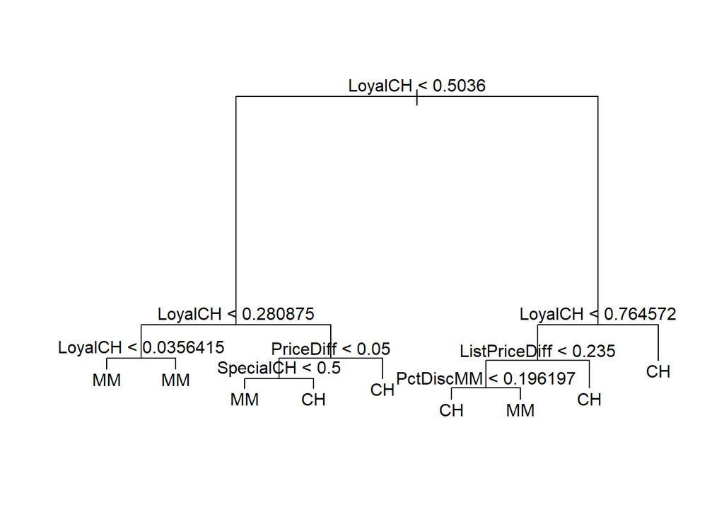

```r
plot(tree.OJ)
text(tree.OJ)
```

##Predict the tree model with test data and build a confusion matrix and calculate the testerror

```r
tree.pred = predict(tree.OJ,OJ.test,type="class")
table(tree.pred,OJ.test$Purchase)
```

```
##
## tree.pred  CH  MM
##        CH 160  38
##        MM   8  64
```

```r
testeeror = 1-mean(tree.pred==OJ.test$Purchase)
testeeror
```

```
## [1] 0.1703704
```

## Using cross validation method to prune the tree and plot the MSE with K

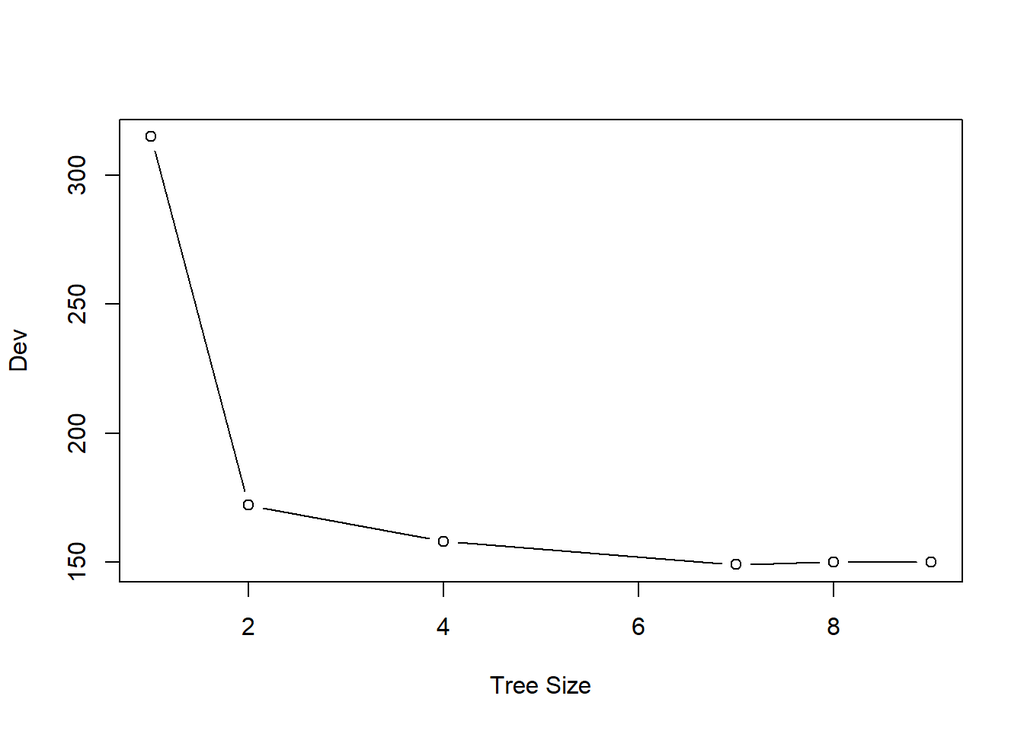

```r
cv.OJ = cv.tree(tree.OJ,FUN=prune.misclass)
plot(cv.OJ$size,cv.OJ$dev,type = "b",xlab="Tree Size", ylab = "Dev")
```

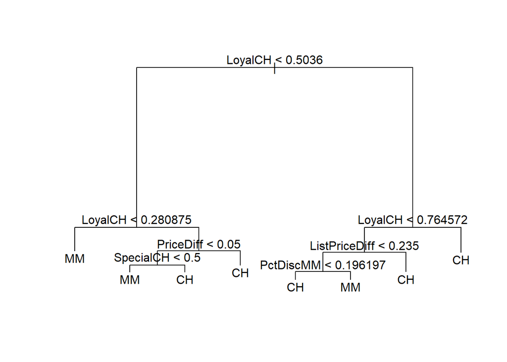

```r
prune.OJ=prune.misclass(tree.OJ,best=8)
plot(prune.OJ)
text(prune.OJ)
```

##Making new prediction

```r
tree.pred2=predict(prune.OJ,OJ.test,type="class")
table(tree.pred2,OJ.test$Purchase)
```

```
##
## tree.pred2  CH  MM
##         CH 160  38
##         MM   8  64
```

```r
testerror2 = 1-mean(tree.pred2==OJ.test$Purchase)
testerror2
```

```
## [1] 0.1703704
```